# Language Diversity in Canada - 2021 Census Update

Dmitry Shkolnik

2025-06-11

## The Language Diversity Index

The Language Diversity Index, introduced by Greenberg (1956), calculates the probability that any two speakers in a population will speak different languages:

$$LDI = 1 - \sum (P_i)^2$$

Where $P_i$ is the proportion of speakers of language $i$. A higher LDI indicates greater linguistic diversity, with a theoretical maximum of 1.

## Setup and Data Acquisition

```r
# Load required libraries
library(cancensus)
library(dplyr)
library(ggplot2)
library(sf)
library(knitr)
library(DT)

# Set dataset for 2021 Census
dataset <- "CA21"
```

## Finding 2021 Language Vectors

Let’s identify the equivalent language vectors in the 2021 census data:

```r
# Search for language vectors in 2021 census
language_search <- find_census_vectors("language spoken most often", dataset = dataset, type = "total")

# Display the results
kable(language_search[1:10, c("vector", "type", "label")],
      caption = "Top 10 Language-related Vectors in 2021 Census")
```

Top 10 Language-related Vectors in 2021 Census

| vector | type | label |
| --- | --- | --- |
| v_CA21_2200 | Total | Total - Language spoken most often at home for the total population excluding institutional residents - 100% data |
| v_CA21_2203 | Total | Single responses |
| v_CA21_2206 | Total | Official languages |
| v_CA21_2209 | Total | English |
| v_CA21_2212 | Total | French |
| v_CA21_2215 | Total | Non-official languages |
| v_CA21_2218 | Total | Indigenous languages |
| v_CA21_2221 | Total | Algonquian languages |
| v_CA21_2224 | Total | Blackfoot |
| v_CA21_2227 | Total | Cree-Innu languages |

```r
# Find the main language vector for 2021
language_total <- find_census_vectors("Total - Language spoken most often at home",
                                    dataset = dataset, type = "total") %>%
  filter(grepl("Total.*Language spoken most often at home.*population", label, ignore.case = TRUE)) %>%
  slice(1)

print(paste("Main language vector:", language_total$vector, "-", language_total$label))
```

```
## [1] "Main language vector: v_CA21_2200 - Total - Language spoken most often at home for the total population excluding institutional residents - 100% data"
```

```r
# Get all child vectors (specific languages)
if(nrow(language_total) > 0) {
  language_children <- child_census_vectors(language_total$vector)

  # Filter out aggregates and keep only specific languages
  language_children <- language_children %>%
    filter(
      !grepl("Multiple responses", label),
      !grepl("Single responses", label),
      !grepl("Official languages", label),
      !grepl("Non-official languages", label)
    ) %>%
    slice_head(n = 50)  # Limit to 50 specific languages for performance

  # Combine total and children vectors
  language_vectors <- bind_rows(language_total, language_children) %>%
    pull(vector)

  cat("Found", length(language_vectors), "language vectors for analysis\n")
} else {
  stop("Could not find main language vector. Check vector search.")
}
```

```
## Found 51 language vectors for analysis
```

## Testing Data Retrieval

Let’s test with a small region first to ensure our approach works:

```r
# Test with Toronto CMA first
test_regions <- list(CMA = "35535")  # Toronto CMA code

# Check if we have language vectors
if(exists("language_vectors") && length(language_vectors) > 0) {
  cat("Testing with", min(10, length(language_vectors)), "vectors...\n")

  test_data <- get_census(
    dataset = dataset,
    regions = test_regions,
    vectors = language_vectors[1:min(10, length(language_vectors))],
    level = "CMA",
    quiet = TRUE
  )

  # Check if data retrieval worked
  if(nrow(test_data) > 0) {
    cat("✓ Data retrieval successful for Toronto CMA\n")
    cat("Retrieved", nrow(test_data), "rows with", ncol(test_data), "columns\n")
  } else {
    cat("❌ Data retrieval returned no rows\n")
  }
} else {
  cat("❌ Language vectors not found - check previous chunk\n")
}
```

```
## Testing with 10 vectors...
```

```
## ✓ Data retrieval successful for Toronto CMA
## Retrieved 1 rows with 19 columns
```

```r
# Get list of all CMAs for analysis
cma_list <- list_census_regions(dataset = dataset) %>%
  filter(level == "CMA", pop > 100000)  # Focus on larger metropolitan areas

cat("Analyzing", nrow(cma_list), "major metropolitan areas\n")
```

```
## Analyzing 41 major metropolitan areas
```

```r
kable(head(cma_list, 10), caption = "Major Canadian Metropolitan Areas (Sample)")
```

Major Canadian Metropolitan Areas (Sample)

| region | name | level | pop | municipal_status | CMA_UID | CD_UID | PR_UID |
| --- | --- | --- | --- | --- | --- | --- | --- |
| 35535 | Toronto | CMA | 6202225 | B | NA | NA | 35 |
| 24462 | Montréal | CMA | 4291732 | B | NA | NA | 24 |
| 59933 | Vancouver | CMA | 2642825 | B | NA | NA | 59 |
| 505 | Ottawa - Gatineau | CMA | 1488307 | B | NA | NA | NA |
| 48825 | Calgary | CMA | 1481806 | B | NA | NA | 48 |
| 48835 | Edmonton | CMA | 1418118 | B | NA | NA | 48 |
| 24421 | Québec | CMA | 839311 | B | NA | NA | 24 |
| 46602 | Winnipeg | CMA | 834678 | B | NA | NA | 46 |
| 35537 | Hamilton | CMA | 785184 | B | NA | NA | 35 |
| 35541 | Kitchener - Cambridge - Waterloo | CMA | 575847 | B | NA | NA | 35 |

## Full Data Retrieval

```r
# Get language data for all major CMAs
if(exists("cma_list") && nrow(cma_list) > 0 && exists("language_vectors") && length(language_vectors) > 0) {
  cat("Retrieving data for", nrow(cma_list), "CMAs with", length(language_vectors), "language vectors...\n")

  # Retrieve data for all CMAs
  language_data <- get_census(
    dataset = dataset,
    regions = list(CMA = cma_list$region),
    vectors = language_vectors,
    level = "CMA",
    labels = "short",
    quiet = TRUE
  )

  cat("✓ Retrieved data for", nrow(language_data), "metropolitan areas\n")
  cat("✓ With", length(language_vectors), "language categories\n")
} else {
  stop("❌ Missing required data: cma_list or language_vectors")
}
```

```
## Retrieving data for 41 CMAs with 51 language vectors...
```

```
## ✓ Retrieved data for 41 metropolitan areas
## ✓ With 51 language categories
```

## Calculate Language Diversity Index

```r
# Function to calculate Language Diversity Index
calculate_ldi <- function(proportions) {
  # Remove any NA values and ensure proportions sum to 1
  proportions <- proportions[!is.na(proportions)]
  proportions <- proportions[proportions > 0]

  if(length(proportions) == 0) return(NA)

  # Normalize to ensure sum = 1
  proportions <- proportions / sum(proportions)

  # Calculate LDI = 1 - sum(pi^2)
  ldi <- 1 - sum(proportions^2)
  return(ldi)
}

# Prepare data for LDI calculation
# We need to extract the language count columns and calculate proportions
language_cols <- language_data %>%
  select(starts_with("v_CA21_")) %>%
  select(-any_of(c("v_CA21_1", "v_CA21_2"))) %>%  # Remove total population columns if present
  names()

# Calculate total language speakers for each CMA (should be first vector - total)
total_col <- language_vectors[1]

ldi_results <- language_data %>%
  select(GeoUID, name = `Region Name`, all_of(language_cols)) %>%
  rowwise() %>%
  mutate(
    # Calculate proportions for each language
    total_speakers = get(total_col),
    # Get proportions for all languages except the total
    language_proportions = list(
      c_across(all_of(language_cols[-1])) / total_speakers
    ),
    # Calculate LDI
    ldi = calculate_ldi(unlist(language_proportions))
  ) %>%
  ungroup() %>%
  select(GeoUID, name, total_speakers, ldi) %>%
  arrange(desc(ldi))

# Display results
cat("Language Diversity Index calculated for", nrow(ldi_results), "metropolitan areas\n")
```

```
## Language Diversity Index calculated for 41 metropolitan areas
```

## Results Visualization

```r
# Create results table
top_diverse <- ldi_results %>%
  filter(!is.na(ldi)) %>%
  mutate(
    rank = row_number(),
    ldi_rounded = round(ldi, 4),
    total_speakers_formatted = scales::comma(total_speakers)
  ) %>%
  select(
    Rank = rank,
    `Metropolitan Area` = name,
    `Language Diversity Index` = ldi_rounded,
    `Total Speakers` = total_speakers_formatted
  )

# Display top 15 most diverse CMAs
kable(head(top_diverse, 15),
      caption = "Top 15 Most Linguistically Diverse Canadian Metropolitan Areas (2021)")
```

Top 15 Most Linguistically Diverse Canadian Metropolitan Areas (2021)

| Rank | Metropolitan Area | Language Diversity Index | Total Speakers |
| --- | --- | --- | --- |
| 1 | Toronto (B) | 0.6703 | 6,161,570 |
| 2 | Vancouver (B) | 0.6690 | 2,619,420 |
| 3 | Montréal (B) | 0.6425 | 4,246,060 |
| 4 | Ottawa - Gatineau (B) | 0.6396 | 1,473,200 |
| 5 | Abbotsford - Mission (B) | 0.5630 | 193,315 |
| 6 | Calgary (B) | 0.5385 | 1,470,355 |
| 7 | Moncton (B) | 0.5326 | 155,475 |
| 8 | Winnipeg (B) | 0.5121 | 826,465 |
| 9 | Kitchener - Cambridge - Waterloo (B) | 0.4850 | 570,890 |
| 10 | Edmonton (B) | 0.4838 | 1,404,625 |
| 11 | Windsor (B) | 0.4399 | 418,935 |
| 12 | Hamilton (B) | 0.4063 | 777,060 |
| 13 | London (B) | 0.4017 | 538,245 |
| 14 | Regina (B) | 0.3996 | 245,920 |
| 15 | Saskatoon (B) | 0.3857 | 313,440 |

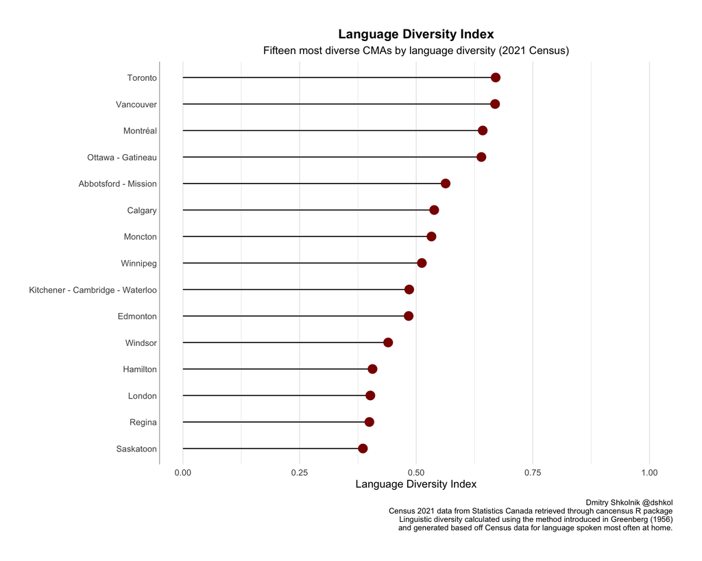

```r
# Install required packages if needed
if(!require(ggalt)) install.packages("ggalt")
if(!require(ggrepel)) install.packages("ggrepel")
if(!require(viridis)) install.packages("viridis")

library(ggalt)
library(ggrepel)
library(viridis)

# Create lollipop chart visualization (top 15 to match original)
top_15 <- ldi_results %>%
  filter(!is.na(ldi)) %>%
  slice_head(n = 15) %>%
  mutate(name_clean = gsub(" \\(.*\\)", "", name))

# Lollipop chart with original styling
lollipop_plot <- ggplot(top_15, aes(y = reorder(name_clean, ldi), x = ldi)) +
  geom_lollipop(point.colour = "darkred", point.size = 4, horizontal = TRUE) +
  scale_x_continuous("Language Diversity Index") +
  expand_limits(x = 1.0) +
  theme_minimal() +
  theme(panel.grid.major.y = element_blank()) +
  theme(axis.line.y = element_line(color = "#2b2b2b", size = 0.15)) +
  theme(axis.text.y = element_text(margin = margin(r = 0, l = 0))) +
  theme(plot.margin = unit(rep(30, 4), "pt")) +
  theme(plot.title = element_text(face = "bold", hjust = 0.5)) +
  theme(plot.subtitle = element_text(hjust = 0.5)) +
  theme(plot.caption = element_text(size = 8, margin = margin(t = 10))) +
  labs(
    y = NULL,
    title = "Language Diversity Index",
    subtitle = "Fifteen most diverse CMAs by language diversity (2021 Census)",
    caption = "Dmitry Shkolnik @dshkol\nCensus 2021 data from Statistics Canada retrieved through cancensus R package\nLinguistic diversity calculated using the method introduced in Greenberg (1956)\nand generated based off Census data for language spoken most often at home."
  )

lollipop_plot
```

## Summary Statistics

```r
# Generate summary statistics
summary_stats <- ldi_results %>%
  filter(!is.na(ldi)) %>%
  summarise(
    n_cmas = n(),
    mean_ldi = mean(ldi),
    median_ldi = median(ldi),
    min_ldi = min(ldi),
    max_ldi = max(ldi),
    sd_ldi = sd(ldi)
  )

cat("Summary Statistics for Language Diversity Index (2021):\n")
```

```
## Summary Statistics for Language Diversity Index (2021):
```

```r
cat("Number of CMAs analyzed:", summary_stats$n_cmas, "\n")
```

```
## Number of CMAs analyzed: 41
```

```r
cat("Mean LDI:", round(summary_stats$mean_ldi, 4), "\n")
```

```
## Mean LDI: 0.3227
```

```r
cat("Median LDI:", round(summary_stats$median_ldi, 4), "\n")
```

```
## Median LDI: 0.2738
```

```r
cat("Range:", round(summary_stats$min_ldi, 4), "to", round(summary_stats$max_ldi, 4), "\n")
```

```
## Range: 0.0407 to 0.6703
```

```r
cat("Standard Deviation:", round(summary_stats$sd_ldi, 4), "\n")
```

```
## Standard Deviation: 0.1751
```

## Comparison with Major Cities

```r
# Focus on Canada's largest metropolitan areas
major_cities <- c("Toronto", "Montréal", "Vancouver", "Calgary", "Edmonton", "Ottawa - Gatineau")

major_cities_ldi <- ldi_results %>%
  filter(grepl(paste(major_cities, collapse = "|"), name, ignore.case = TRUE)) %>%
  arrange(desc(ldi)) %>%
  mutate(rank_overall = match(name, top_diverse$`Metropolitan Area`))

kable(major_cities_ldi %>%
        select(`Metropolitan Area` = name,
               `LDI` = ldi,
               `Overall Rank` = rank_overall),
      caption = "Language Diversity in Canada's Major Metropolitan Areas",
      digits = 4)
```

Language Diversity in Canada’s Major Metropolitan Areas

| Metropolitan Area | LDI | Overall Rank |
| --- | --- | --- |
| Toronto (B) | 0.6703 | 1 |
| Vancouver (B) | 0.6690 | 2 |
| Montréal (B) | 0.6425 | 3 |
| Ottawa - Gatineau (B) | 0.6396 | 4 |
| Calgary (B) | 0.5385 | 6 |
| Edmonton (B) | 0.4838 | 10 |

## Population vs Linguistic Diversity

Let’s explore the relationship between metropolitan area population size and linguistic diversity:

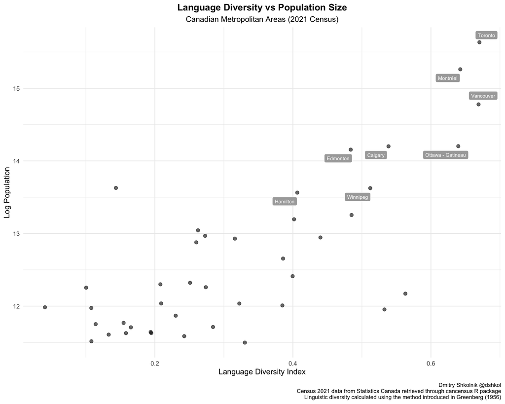

```r
# Create scatter plot with labeled points
plot_theme <- theme_minimal() +
  theme(plot.title = element_text(face = "bold", hjust = 0.5)) +
  theme(plot.subtitle = element_text(hjust = 0.5)) +
  theme(plot.caption = element_text(size = 8, margin = margin(t = 10)))

# Identify key points for labeling
labeled_points <- c("Toronto", "Vancouver", "Montréal", "Ottawa - Gatineau", "Calgary", "Edmonton", "Winnipeg", "Hamilton")
label_data <- ldi_results %>%
  filter(grepl(paste(labeled_points, collapse = "|"), name, ignore.case = TRUE)) %>%
  mutate(name_clean = gsub(" \\(.*\\)", "", name))

# Scatter plot with log population
ggplot(ldi_results %>% mutate(name_clean = gsub(" \\(.*\\)", "", name)),
       aes(x = ldi, y = log(total_speakers))) +
  geom_point(alpha = 0.6, size = 2) +
  geom_label_repel(data = label_data,
    aes(x = ldi, y = log(total_speakers), label = name_clean),
    size = 2.5,
    color = 'white',
    fill = "darkgrey",
    box.padding = unit(0.35, "lines"),
    point.padding = unit(0.5, "lines"),
    segment.color = 'grey50') +
  scale_x_continuous("Language Diversity Index") +
  scale_y_continuous("Log Population") +
  plot_theme +
  labs(title = "Language Diversity vs Population Size",
       subtitle = "Canadian Metropolitan Areas (2021 Census)",
       caption = "Dmitry Shkolnik @dshkol\nCensus 2021 data from Statistics Canada retrieved through cancensus R package\nLinguistic diversity calculated using the method introduced in Greenberg (1956)")
```

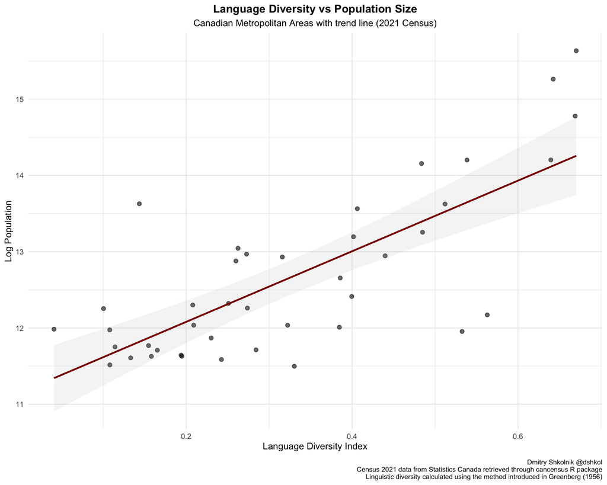

```r
# Add trend line with confidence interval
ggplot(ldi_results, aes(x = ldi, y = log(total_speakers))) +
  geom_point(alpha = 0.6, size = 2) +
  geom_smooth(method = 'lm', colour = "darkred", alpha = 0.1) +
  scale_x_continuous("Language Diversity Index") +
  scale_y_continuous("Log Population") +
  plot_theme +
  labs(title = "Language Diversity vs Population Size",
       subtitle = "Canadian Metropolitan Areas with trend line (2021 Census)",
       caption = "Dmitry Shkolnik @dshkol\nCensus 2021 data from Statistics Canada retrieved through cancensus R package\nLinguistic diversity calculated using the method introduced in Greenberg (1956)")
```

## Spatial Analysis: Language Diversity within Metropolitan Areas

Let’s examine the spatial distribution of language diversity within Canada’s largest metropolitan areas at a finer geographic resolution:

```r
# Get spatial data for Toronto at Census Tract level for detailed analysis
if(!require(sf)) install.packages("sf")
library(sf)

# Select Toronto for detailed spatial analysis
toronto_region <- list(CMA = "35535")  # Toronto CMA code

cat("Retrieving spatial data for Toronto at Census Tract level...\n")
```

```
## Retrieving spatial data for Toronto at Census Tract level...
```

```r
# Get Toronto census tract data with geometry
toronto_spatial <- get_census(
  dataset = dataset,
  regions = toronto_region,
  vectors = language_vectors,
  level = "CT",  # Census Tract level for good detail
  geo_format = "sf",
  labels = "short",
  quiet = TRUE
)

# Calculate LDI for each census tract
toronto_spatial_clean <- toronto_spatial %>%
  st_drop_geometry()

# Calculate LDI for Toronto CTs
toronto_ldi_spatial <- toronto_spatial_clean %>%
  select(GeoUID, all_of(language_cols)) %>%
  rowwise() %>%
  mutate(
    total_speakers = get(total_col),
    language_counts = list(
      c_across(all_of(setdiff(language_cols, total_col)))
    ),
    ldi = calculate_ldi(unlist(language_counts) / total_speakers)
  ) %>%
  ungroup() %>%
  select(GeoUID, ldi)

# Join back to spatial data
toronto_map_data <- toronto_spatial %>%
  left_join(toronto_ldi_spatial, by = "GeoUID") %>%
  filter(!is.na(ldi))

cat("Prepared spatial data for", nrow(toronto_map_data), "census tracts\n")
```

```
## Prepared spatial data for 1224 census tracts
```

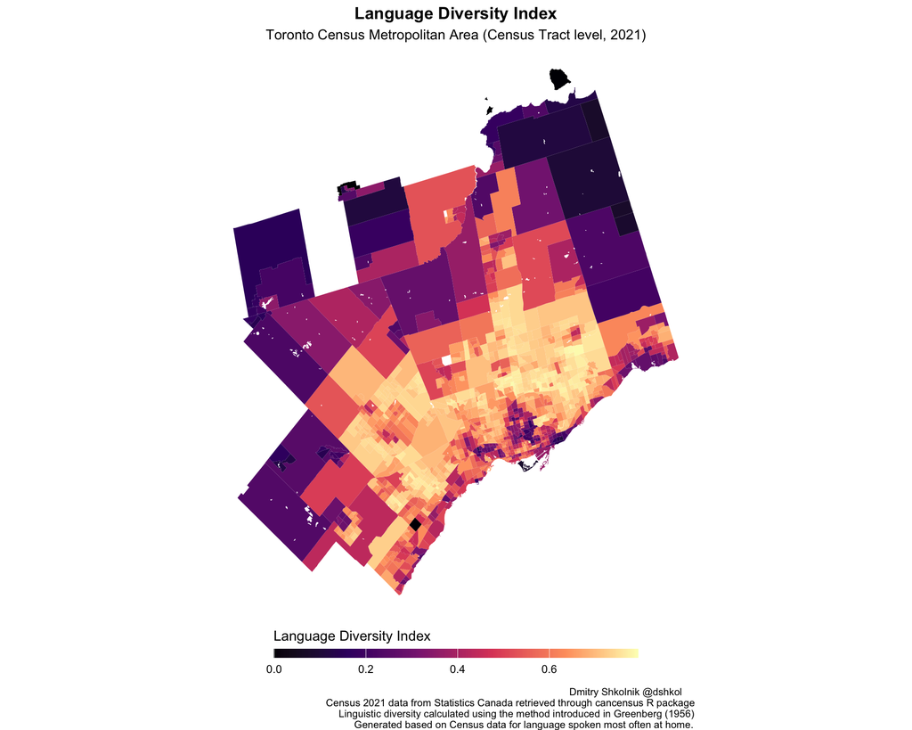

```r
# Create Toronto language diversity map
map_theme <- theme_void() +
  theme(plot.title = element_text(face = "bold", hjust = 0.5)) +
  theme(plot.subtitle = element_text(hjust = 0.5)) +
  theme(plot.caption = element_text(size = 8, margin = margin(t = 10), hjust = 0.95)) +
  theme(legend.position = "bottom")

toronto_map <- ggplot(toronto_map_data) +
  geom_sf(aes(fill = ldi), colour = NA) +
  scale_fill_viridis_c("Language Diversity Index", option = "magma", direction = 1) +
  map_theme +
  coord_sf(datum = NA) +
  guides(fill = guide_colourbar(title.position = "top", barwidth = 20, barheight = 0.5)) +
  labs(
    title = "Language Diversity Index",
    subtitle = "Toronto Census Metropolitan Area (Census Tract level, 2021)",
    caption = "Dmitry Shkolnik @dshkol\nCensus 2021 data from Statistics Canada retrieved through cancensus R package\nLinguistic diversity calculated using the method introduced in Greenberg (1956)\nGenerated based on Census data for language spoken most often at home."
  )

toronto_map
```

```r
# Summary of spatial patterns
spatial_summary <- toronto_map_data %>%
  st_drop_geometry() %>%
  summarise(
    n_tracts = n(),
    mean_ldi = mean(ldi, na.rm = TRUE),
    median_ldi = median(ldi, na.rm = TRUE),
    min_ldi = min(ldi, na.rm = TRUE),
    max_ldi = max(ldi, na.rm = TRUE),
    sd_ldi = sd(ldi, na.rm = TRUE)
  )

cat("Toronto CMA Spatial Analysis Summary:\n")
```

```
## Toronto CMA Spatial Analysis Summary:
```

```r
cat("Number of Census Tracts:", spatial_summary$n_tracts, "\n")
```

```
## Number of Census Tracts: 1224
```

```r
cat("Mean LDI:", round(spatial_summary$mean_ldi, 4), "\n")
```

```
## Mean LDI: 0.593
```

```r
cat("Range:", round(spatial_summary$min_ldi, 4), "to", round(spatial_summary$max_ldi, 4), "\n")
```

```
## Range: 0 to 0.7928
```

```r
cat("Standard Deviation:", round(spatial_summary$sd_ldi, 4), "\n")
```

```
## Standard Deviation: 0.1689
```

```r
cat("\nThis reveals significant spatial heterogeneity in language diversity within the Toronto metropolitan area.\n")
```

```
##
## This reveals significant spatial heterogeneity in language diversity within the Toronto metropolitan area.
```

## Conclusions

```r
# Get the most diverse CMA
most_diverse <- ldi_results %>%
  filter(!is.na(ldi)) %>%
  slice_max(ldi, n = 1)

cat("Based on 2021 Census data:\n")
```

```
## Based on 2021 Census data:
```

```r
cat("• Most linguistically diverse Canadian metropolitan area:", most_diverse$name, "\n")
```

[output not shown]

```r
cat("• LDI Score:", round(most_diverse$ldi, 4), "\n")
```

```
## • LDI Score: 0.6703
```

```r
cat("• This represents a", round(most_diverse$ldi * 100, 1), "% probability that two randomly selected residents speak different mother tongues\n")
```

```
## • This represents a 67 % probability that two randomly selected residents speak different mother tongues
```

```r
# Toronto ranking
toronto_rank <- which(grepl("Toronto", top_diverse$`Metropolitan Area`))
if(length(toronto_rank) > 0) {
  cat("• Toronto ranks #", toronto_rank, "in linguistic diversity\n")
}
```

```
## • Toronto ranks # 1 in linguistic diversity
```

## Technical Notes

Key differences from the original 2017 analysis: - Uses 2021 Census dataset (CA21) instead of 2016 (CA16) - Updated vector identification methods for 2021 data structure - Refined data processing to handle 2021 census data format